# 1. Load the required libraries and read the dataset

```python
import warnings
warnings.filterwarnings("ignore")
import numpy as np
import pandas as pd
import seaborn as sns
import matplotlib.pyplot as plt
from sklearn.preprocessing import StandardScaler,MinMaxScaler
from sklearn.preprocessing import OneHotEncoder
from sklearn.preprocessing import LabelEncoder
from scipy.spatial import distance
from scipy import stats
from scipy.stats import zscore
from scipy.cluster.hierarchy import linkage, dendrogram, fcluster
from sklearn.cluster import AgglomerativeClustering
from sklearn.decomposition import PCA
from sklearn.cluster import KMeans
from sklearn.metrics import silhouette_score
from sklearn.cluster import AgglomerativeClustering
```

```python
df = pd.read_csv(r"C:\Users\SANATH\Downloads\renttherunway.csv")
```

# 2. Checking the first few samples, shape, info of the data

```python
df.head()
```

|  | Unnamed: 0 | fit | user_id | bust size | item_id | weight | rating | rented for | review_text | body type | review_summary | category | height | size | age | review_date |
| --- | --- | --- | --- | --- | --- | --- | --- | --- | --- | --- | --- | --- | --- | --- | --- | --- |
| 0 | 0 | fit | 420272 | 34d | 2260466 | 137lbs | 10.0 | vacation | An adorable romper! Belt and zipper were a lit... | hourglass | So many compliments! | romper | 5' 8" | 14 | 28.0 | April 20, 2016 |
| 1 | 1 | fit | 273551 | 34b | 153475 | 132lbs | 10.0 | other | I rented this dress for a photo shoot. The the... | straight & narrow | I felt so glamourous!!! | gown | 5' 6" | 12 | 36.0 | June 18, 2013 |
| 2 | 2 | fit | 360448 | NaN | 1063761 | NaN | 10.0 | party | This hugged in all the right places! It was a ... | NaN | It was a great time to celebrate the (almost) ... | sheath | 5' 4" | 4 | 116.0 | December 14, 2015 |
| 3 | 3 | fit | 909926 | 34c | 126335 | 135lbs | 8.0 | formal affair | I rented this for my company's black tie award... | pear | Dress arrived on time and in perfect condition. | dress | 5' 5" | 8 | 34.0 | February 12, 2014 |
| 4 | 4 | fit | 151944 | 34b | 616682 | 145lbs | 10.0 | wedding | I have always been petite in my upper body and... | athletic | Was in love with this dress !!! | gown | 5' 9" | 12 | 27.0 | September 26, 2016 |

```python
df.shape
```

```
(192544, 16)
```

```python
df.describe().T
```

|  | count | mean | std | min | 25% | 50% | 75% | max |
| --- | --- | --- | --- | --- | --- | --- | --- | --- |
| Unnamed: 0 | 192544.0 | 9.627150e+04 | 55582.809453 | 0.0 | 48135.75 | 96271.5 | 144407.25 | 192543.0 |
| user_id | 192544.0 | 4.994941e+05 | 289059.719328 | 9.0 | 250654.25 | 499419.0 | 750974.00 | 999997.0 |
| item_id | 192544.0 | 1.045684e+06 | 805314.802324 | 123373.0 | 195076.00 | 948396.0 | 1678888.00 | 2966087.0 |
| rating | 192462.0 | 9.092371e+00 | 1.430044 | 2.0 | 8.00 | 10.0 | 10.00 | 10.0 |
| size | 192544.0 | 1.224518e+01 | 8.494877 | 0.0 | 8.00 | 12.0 | 16.00 | 58.0 |
| age | 191584.0 | 3.387102e+01 | 8.058083 | 0.0 | 29.00 | 32.0 | 37.00 | 117.0 |

- Average age is 33.
- Average Rating is 9.09 with minimum at 2 and maximum 10.

```python
df.info()
```

```
<class 'pandas.core.frame.DataFrame'>
RangeIndex: 192544 entries, 0 to 192543
Data columns (total 16 columns):
 #   Column          Non-Null Count   Dtype
---  ------          --------------   -----
 0   Unnamed: 0      192544 non-null  int64
 1   fit             192544 non-null  object
 2   user_id         192544 non-null  int64
 3   bust size       174133 non-null  object
 4   item_id         192544 non-null  int64
 5   weight          162562 non-null  object
 6   rating          192462 non-null  float64
 7   rented for      192534 non-null  object
 8   review_text     192482 non-null  object
 9   body type       177907 non-null  object
 10  review_summary  192199 non-null  object
 11  category        192544 non-null  object
 12  height          191867 non-null  object
 13  size            192544 non-null  int64
 14  age             191584 non-null  float64
 15  review_date     192544 non-null  object
dtypes: float64(2), int64(4), object(10)
memory usage: 23.5+ MB
```

- 10 Categorical Columns
- 6 Numerical columns

# 3. Check for any duplicate records in dataset and drop them

```python
df[df.duplicated()].sum()
```

```
Unnamed: 0        0.0
fit               0.0
user_id           0.0
bust size         0.0
item_id           0.0
weight            0.0
rating            0.0
rented for        0.0
review_text       0.0
body type         0.0
review_summary    0.0
category          0.0
height            0.0
size              0.0
age               0.0
review_date       0.0
dtype: float64
```

- No Duplicate Values

# 4. Dropping redundant columns

```python
df.drop(['user_id'], axis=1, inplace=True)
df.drop(['review_text'],axis=1,inplace=True)
```

```python
df.drop(['review_summary'],axis=1,inplace=True)
df.drop(['review_date'],axis=1,inplace=True)
```

```python
df.head()
```

|  | Unnamed: 0 | fit | bust size | item_id | weight | rating | rented for | body type | category | height | size | age |
| --- | --- | --- | --- | --- | --- | --- | --- | --- | --- | --- | --- | --- |
| 0 | 0 | fit | 34d | 2260466 | 137lbs | 10.0 | vacation | hourglass | romper | 5' 8" | 14 | 28.0 |
| 1 | 1 | fit | 34b | 153475 | 132lbs | 10.0 | other | straight & narrow | gown | 5' 6" | 12 | 36.0 |
| 2 | 2 | fit | NaN | 1063761 | NaN | 10.0 | party | NaN | sheath | 5' 4" | 4 | 116.0 |
| 3 | 3 | fit | 34c | 126335 | 135lbs | 8.0 | formal affair | pear | dress | 5' 5" | 8 | 34.0 |
| 4 | 4 | fit | 34b | 616682 | 145lbs | 10.0 | wedding | athletic | gown | 5' 9" | 12 | 27.0 |

# 5. Checking weight column for string type 'lbs'

```python
df['weight'].str.contains('lbs').any()
```

```
True
```

```python
df['weight'] = df['weight'].str.replace('lbs', '').str.strip().astype(float)
```

```python
df['weight'].info()
```

```
<class 'pandas.core.series.Series'>
RangeIndex: 192544 entries, 0 to 192543
Series name: weight
Non-Null Count   Dtype
--------------   -----
162562 non-null  float64
dtypes: float64(1)
memory usage: 1.5 MB
```

# 6. replacing 'party: cocktail' with 'party' in 'rented for' column

```python
df['rented for'].unique()
```

```
array(['vacation', 'other', 'party', 'formal affair', 'wedding', 'date',
       'everyday', 'work', nan, 'party: cocktail'], dtype=object)
```

```python
df['rented for'] = df['rented for'].str.replace('party: cocktail', 'party')
df['rented for'].value_counts()
```

```
wedding          57784
formal affair    40408
party            35627
everyday         16822
other            15388
work             15042
date              7388
vacation          4075
Name: rented for, dtype: int64
```

# 7. Convert feet to inches in 'height' column and then to float datatype

```python
df['height'].head()
```

```
0    5' 8"
1    5' 6"
2    5' 4"
3    5' 5"
4    5' 9"
Name: height, dtype: object
```

```python
def convert_to_inches(height):
    if isinstance(height, float):
        return height
    feet, inches = map(int, height.replace('"', '').split("'"))
    total_inches = (feet * 12) + inches
    return float(total_inches)
```

```python
df['height'] = df['height'].apply(convert_to_inches)
```

```python
df.head()
```

|  | Unnamed: 0 | fit | bust size | item_id | weight | rating | rented for | body type | category | height | size | age |
| --- | --- | --- | --- | --- | --- | --- | --- | --- | --- | --- | --- | --- |
| 0 | 0 | fit | 34d | 2260466 | 137.0 | 10.0 | vacation | hourglass | romper | 68.0 | 14 | 28.0 |
| 1 | 1 | fit | 34b | 153475 | 132.0 | 10.0 | other | straight & narrow | gown | 66.0 | 12 | 36.0 |
| 2 | 2 | fit | NaN | 1063761 | NaN | 10.0 | party | NaN | sheath | 64.0 | 4 | 116.0 |
| 3 | 3 | fit | 34c | 126335 | 135.0 | 8.0 | formal affair | pear | dress | 65.0 | 8 | 34.0 |
| 4 | 4 | fit | 34b | 616682 | 145.0 | 10.0 | wedding | athletic | gown | 69.0 | 12 | 27.0 |

# 8. Checking for missing values in each column and imputing them.

```python
df.isna().sum()
```

```
Unnamed: 0        0
fit               0
bust size     18411
item_id           0
weight        29982
rating           82
rented for       10
body type     14637
category          0
height          677
size              0
age             960
dtype: int64
```

```python
df.info()
```

```
<class 'pandas.core.frame.DataFrame'>
RangeIndex: 192544 entries, 0 to 192543
Data columns (total 12 columns):
 #   Column      Non-Null Count   Dtype
---  ------      --------------   -----
 0   Unnamed: 0  192544 non-null  int64
 1   fit         192544 non-null  object
 2   bust size   174133 non-null  object
 3   item_id     192544 non-null  int64
 4   weight      162562 non-null  float64
 5   rating      192462 non-null  float64
 6   rented for  192534 non-null  object
 7   body type   177907 non-null  object
 8   category    192544 non-null  object
 9   height      191867 non-null  float64
 10  size        192544 non-null  int64
 11  age         191584 non-null  float64
dtypes: float64(4), int64(3), object(5)
memory usage: 17.6+ MB
```

```python
df['bust size'].fillna(df['bust size'].mode()[0],inplace=True)
df['weight'].fillna(df['weight'].median(),inplace=True)
df['rating'].fillna(df['rating'].mean(),inplace=True)
df['rented for'].fillna(df['rented for'].mode()[0],inplace=True)
df['body type'].fillna(df['body type'].mode()[0],inplace=True)
df['height'].fillna(df['height'].median(), inplace=True)
df['age'].fillna(df['age'].mean(), inplace=True)
```

```python
df.isna().sum()
```

```
Unnamed: 0    0
fit           0
bust size     0
item_id       0
weight        0
rating        0
rented for    0
body type     0
category      0
height        0
size          0
age           0
dtype: int64
```

# 9. Statistical summary for numerical and categorical columns

```python
df.describe()
```

|  | Unnamed: 0 | item_id | weight | rating | height | size | age |
| --- | --- | --- | --- | --- | --- | --- | --- |
| count | 192544.000000 | 1.925440e+05 | 192544.000000 | 192544.000000 | 192544.000000 | 192544.000000 | 192544.000000 |
| mean | 96271.500000 | 1.045684e+06 | 137.019284 | 9.092371 | 65.309529 | 12.245175 | 33.871017 |
| std | 55582.809453 | 8.053148e+05 | 20.141448 | 1.429740 | 2.658857 | 8.494877 | 8.037969 |
| min | 0.000000 | 1.233730e+05 | 50.000000 | 2.000000 | 54.000000 | 0.000000 | 0.000000 |
| 25% | 48135.750000 | 1.950760e+05 | 125.000000 | 8.000000 | 63.000000 | 8.000000 | 29.000000 |
| 50% | 96271.500000 | 9.483960e+05 | 135.000000 | 10.000000 | 65.000000 | 12.000000 | 32.000000 |
| 75% | 144407.250000 | 1.678888e+06 | 145.000000 | 10.000000 | 67.000000 | 16.000000 | 37.000000 |
| max | 192543.000000 | 2.966087e+06 | 300.000000 | 10.000000 | 78.000000 | 58.000000 | 117.000000 |

- The average rating recorded for the products is 9.09 with highest rating 10.
- The customer base have a minimum height of 54 inches and maximum height of 78 inches.

```python
df['fit'].value_counts()
```

```
fit      142058
small     25779
large     24707
Name: fit, dtype: int64
```

- Most number of customers prefer fit size

```python
df['bust size'].value_counts()
```

```
34b    45696
34c    23139
34d    18029
36c    13516
32d    11196
       ...
28h        1
46f        1
42j        1
28i        1
44h        1
Name: bust size, Length: 106, dtype: int64
```

- 34b is the most ordered bust size of clothes.
- While 28h, 46f, 42j, 28i, 44h were least ordered.

```python
df['rented for'].value_counts()
```

```
wedding          57794
formal affair    40408
party            35627
everyday         16822
other            15388
work             15042
date              7388
vacation          4075
Name: rented for, dtype: int64
```

- Most customers rent their clothes for Weddings followed by Formal affairs and Parties.
- There were less instances of people renting clothes for vacation.

```python
df['body type'].value_counts()
```

```
hourglass            69986
athletic             43667
pear                 22135
petite               22131
full bust            15006
straight & narrow    14742
apple                 4877
Name: body type, dtype: int64
```

- Most number of customers mentioned their body type to be hourgalss followed by athletic.
- The least recorded type was apple.

```python
df['category'].value_counts()
```

```
dress         92884
gown          44381
sheath        19316
shift          5365
jumpsuit       5184
              ...
caftan            4
overcoat          2
sweatpants        2
crewneck          1
buttondown        1
Name: category, Length: 68, dtype: int64
```

- 'Dress' and 'Gown' are top twp categories of clothes rented by customer.
- 'Crewneck' abd 'buttondown' are bottom two categories.

```python
df.drop(['Unnamed: 0'], axis=1, inplace=True)
df.drop(['item_id'], axis=1, inplace=True)
```

```python
df.head()
```

|  | fit | bust size | weight | rating | rented for | body type | category | height | size | age |
| --- | --- | --- | --- | --- | --- | --- | --- | --- | --- | --- |
| 0 | fit | 34d | 137.0 | 10.0 | vacation | hourglass | romper | 68.0 | 14 | 28.0 |
| 1 | fit | 34b | 132.0 | 10.0 | other | straight & narrow | gown | 66.0 | 12 | 36.0 |
| 2 | fit | 34b | 135.0 | 10.0 | party | hourglass | sheath | 64.0 | 4 | 116.0 |
| 3 | fit | 34c | 135.0 | 8.0 | formal affair | pear | dress | 65.0 | 8 | 34.0 |
| 4 | fit | 34b | 145.0 | 10.0 | wedding | athletic | gown | 69.0 | 12 | 27.0 |

# 10. Finding Ouliers and capping them with upper limit and lower limit

```python
Q1 = df['age'].quantile(0.25)
Q3 = df['age'].quantile(0.75)
IQR = Q3 - Q1
lower_bound = Q1 - 1.5*IQR
upper_bound = Q3 + 1.5*IQR

outliers = (df['age'] < lower_bound) | (df['age'] > upper_bound)
outliers.value_counts()
```

```
False    182290
True      10254
Name: age, dtype: int64
```

```python
df['age'].where(df['age'] <= upper_bound, upper_bound, inplace=True)
```

```python
df['age'].where(df['age'] >= lower_bound, lower_bound, inplace=True)
```

```python
Q1 = df['age'].quantile(0.25)
Q3 = df['age'].quantile(0.75)
IQR = Q3 - Q1
lower_bound = Q1 - 1.5*IQR
upper_bound = Q3 + 1.5*IQR

outliers = (df['age'] < lower_bound) | (df['age'] > upper_bound)
outliers.value_counts()
```

```
False    192544
Name: age, dtype: int64
```

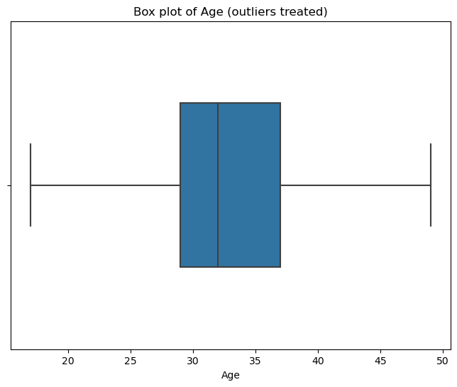

```python
plt.figure(figsize=(8,6))
sns.boxplot(x=df['age'], width=0.5)
plt.title('Box plot of Age (outliers treated)')
plt.xlabel('Age')
plt.show()
```

# 11. Distribution of column 'rented for'.

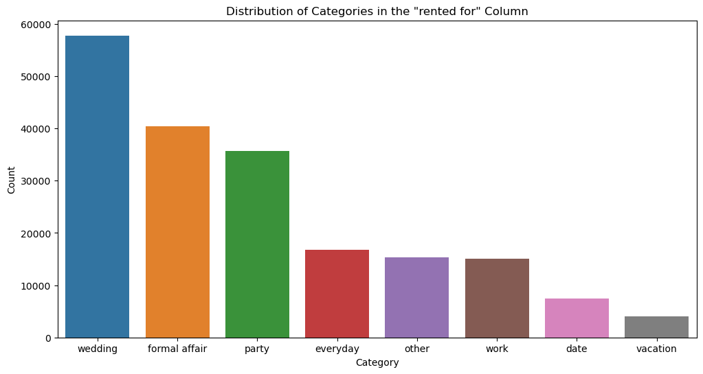

```python
plt.figure(figsize=(12,6))
sns.countplot(x='rented for', data=df,  order=df['rented for'].value_counts().index)
plt.title('Distribution of Categories in the "rented for" Column')
plt.xlabel('Category')
plt.ylabel('Count')
plt.show()
```

# DATA PREPARATION FOR MODEL BUILDING

# 12. Label Encoding categorical variables

```python
cat = ['fit', 'bust size', 'rented for', 'body type', 'category']
le = LabelEncoder()

for i in cat:
    df[i] = df[[i]].apply(le.fit_transform)
```

```python
df.head()
```

|  | fit | bust size | weight | rating | rented for | body type | category | height | size | age |
| --- | --- | --- | --- | --- | --- | --- | --- | --- | --- | --- |
| 0 | 0 | 39 | 137.0 | 10.0 | 5 | 3 | 44 | 68.0 | 14 | 28.0 |
| 1 | 0 | 37 | 132.0 | 10.0 | 3 | 6 | 20 | 66.0 | 12 | 36.0 |
| 2 | 0 | 37 | 135.0 | 10.0 | 4 | 3 | 45 | 64.0 | 4 | 49.0 |
| 3 | 0 | 38 | 135.0 | 8.0 | 2 | 4 | 16 | 65.0 | 8 | 34.0 |
| 4 | 0 | 37 | 145.0 | 10.0 | 6 | 1 | 20 | 69.0 | 12 | 27.0 |

# 13. Standardize the columns, so that values are in a particular range

```python
df1 = df.copy()
normalized_feature = StandardScaler().fit_transform(df1.values)
nf_df = pd.DataFrame(normalized_feature, index=df1.index, columns=df1.columns)
```

```python
nf_df.head()
```

|  | fit | bust size | weight | rating | rented for | body type | category | height | size | age |
| --- | --- | --- | --- | --- | --- | --- | --- | --- | --- | --- |
| 0 | -0.556291 | -0.004640 | -0.000957 | 0.634822 | 0.514420 | 0.020953 | 1.569310 | 1.011893 | 0.206575 | -0.793484 |
| 1 | -0.556291 | -0.187210 | -0.249202 | 0.634822 | -0.456753 | 1.927582 | -0.307247 | 0.259688 | -0.028862 | 0.357032 |
| 2 | -0.556291 | -0.187210 | -0.100255 | 0.634822 | 0.028833 | 0.020953 | 1.647500 | -0.492517 | -0.970608 | 2.226620 |
| 3 | -0.556291 | -0.095925 | -0.100255 | -0.764037 | -0.942340 | 0.656496 | -0.620006 | -0.116415 | -0.499735 | 0.069403 |
| 4 | -0.556291 | -0.187210 | 0.396235 | 0.634822 | 1.000007 | -1.250132 | -0.307247 | 1.387995 | -0.028862 | -0.937299 |

# PRINCIPAL COMPONENT ANALYSIS AND CLUSTERING.

# 14. Applying PCA on the above dataset and determine the number of PCA components to be used so that 90-95% of the variance in data is explained by the same.

```python
## step 1: calculate the covariance matrix
cov_mat = np.cov(nf_df.T)
cov_mat
```

```
array([[ 1.00000519e+00,  9.05525666e-03,  1.36712983e-02,
        -2.45017128e-01,  8.35378787e-03, -7.61016810e-03,
         3.35892077e-04,  1.44717645e-04,  6.54006939e-02,
         8.67163272e-04],
       [ 9.05525666e-03,  1.00000519e+00,  5.68663389e-01,
        -2.09463072e-02, -2.07814670e-03, -2.15702411e-01,
        -1.09647683e-02,  1.47036167e-01,  6.27115858e-01,
         1.72328174e-01],
       [ 1.36712983e-02,  5.68663389e-01,  1.00000519e+00,
        -2.07939053e-02,  9.70156108e-03, -2.34400313e-01,
        -1.44172746e-02,  3.49055850e-01,  7.23391050e-01,
         7.09664989e-02],
       [-2.45017128e-01, -2.09463072e-02, -2.07939053e-02,
         1.00000519e+00,  1.28842617e-02,  4.73487321e-03,
        -2.36044968e-02,  1.76881992e-03, -3.67259761e-02,
        -4.13739940e-02],
       [ 8.35378787e-03, -2.07814670e-03,  9.70156108e-03,
         1.28842617e-02,  1.00000519e+00, -9.08626233e-03,
        -5.76351186e-02, -1.70706029e-02,  4.87422452e-03,
        -3.73073385e-02],
       [-7.61016810e-03, -2.15702411e-01, -2.34400313e-01,
         4.73487321e-03, -9.08626233e-03,  1.00000519e+00,
        -1.85295641e-03, -1.33577071e-01, -2.14155816e-01,
        -4.70891167e-02],
       [ 3.35892077e-04, -1.09647683e-02, -1.44172746e-02,
        -2.36044968e-02, -5.76351186e-02, -1.85295641e-03,
         1.00000519e+00, -4.34401436e-03, -5.62602705e-03,
         2.62505735e-02],
       [ 1.44717645e-04,  1.47036167e-01,  3.49055850e-01,
         1.76881992e-03, -1.70706029e-02, -1.33577071e-01,
        -4.34401436e-03,  1.00000519e+00,  2.28425433e-01,
        -4.91103373e-03],
       [ 6.54006939e-02,  6.27115858e-01,  7.23391050e-01,
        -3.67259761e-02,  4.87422452e-03, -2.14155816e-01,
        -5.62602705e-03,  2.28425433e-01,  1.00000519e+00,
         1.58084784e-01],
       [ 8.67163272e-04,  1.72328174e-01,  7.09664989e-02,
        -4.13739940e-02, -3.73073385e-02, -4.70891167e-02,
         2.62505735e-02, -4.91103373e-03,  1.58084784e-01,
         1.00000519e+00]])
```

```python
## step2: calculate the eigen values and eigen vectors

eig_vals, eig_vects = np.linalg.eig(cov_mat)
print('eigein vals:', '\n', eig_vals)
print('\n')
print('eigein vectors:','\n', eig_vects)
```

```
eigein vals:
 [2.55260794 0.25625096 0.41677432 1.24955949 0.75075723 1.08427008
 1.01611285 0.83907962 0.94521441 0.88942504]


eigein vectors:
 [[ 3.78394400e-02  5.23863873e-02 -3.65638088e-02  6.85809352e-01
   6.89487444e-01 -1.87300761e-01  7.06750577e-02  8.92833090e-02
  -2.65795343e-02 -2.23788492e-03]
 [ 4.96704727e-01  1.07662834e-01 -7.89535604e-01 -1.82530302e-02
  -5.18141475e-02  7.29696274e-02 -1.86417537e-01  2.42866954e-01
   7.02335812e-03 -1.27275410e-01]
 [ 5.42728341e-01  6.70101421e-01  4.54344990e-01 -5.30387447e-02
  -3.97752160e-02 -7.29584585e-02  8.26773523e-02  5.14327742e-02
  -1.04747418e-02 -1.75134105e-01]
 [-3.70074406e-02  7.42026453e-03  6.05959659e-04 -6.99959534e-01
   7.01120798e-01  4.60984435e-02 -3.84221920e-02  1.06719169e-01
   2.28723573e-02 -3.93426172e-02]
 [-2.98938342e-04 -2.99481810e-03 -1.48570158e-02 -4.84263730e-02
  -2.20042148e-02 -5.96622608e-01 -3.76983278e-01 -2.18051427e-01
   6.68678762e-01 -6.47168590e-02]
 [-2.54099249e-01  1.95607472e-02 -2.70677386e-02  4.87987488e-02
   3.75939412e-03  5.54018575e-02 -1.32666341e-01 -1.70493210e-01
  -1.67376513e-01 -9.24213330e-01]
 [-7.97500370e-03  6.21817765e-03 -7.06470315e-03  9.49497029e-02
   4.20625004e-02  5.60069488e-01  3.76081397e-01  2.90834702e-02
   7.15071891e-01 -1.47561570e-01]
 [ 2.70699304e-01 -1.10478655e-01 -2.12368690e-01 -9.94356741e-02
   7.08817053e-02 -1.71942104e-01  5.28765650e-01 -7.31013375e-01
  -1.04418637e-01 -7.95090353e-03]
 [ 5.45447617e-01 -7.20925445e-01  3.40859895e-01  1.82874166e-02
   1.54110391e-02  1.00573617e-02 -8.03882321e-02  1.52290167e-01
   1.30946886e-03 -1.90364320e-01]
 [ 1.43204936e-01  6.48391662e-02  8.11027058e-02  1.12303788e-01
   1.45741650e-01  4.99774833e-01 -6.03930775e-01 -5.32894703e-01
  -3.51052121e-02  1.87460411e-01]]
```

```python
## scree plot
total = sum(eig_vals)
var_exp = [(i/total)*100 for i in sorted(eig_vals, reverse=True)]
cum_var_exp = np.cumsum(var_exp)
print('Explained Variance: ',var_exp)
print('\n')
print('Cummulative Variance: ',cum_var_exp)
```

```
Explained Variance:  [25.525946788142186, 12.495529972909102, 10.842644513110358, 10.161075760950961, 9.452094971638507, 8.894204236774693, 8.390752583119685, 7.507533314669233, 4.167721585463185, 2.5624962732220866]


Cummulative Variance:  [ 25.52594679  38.02147676  48.86412127  59.02519704  68.47729201
  77.37149624  85.76224883  93.26978214  97.43750373 100.        ]
```

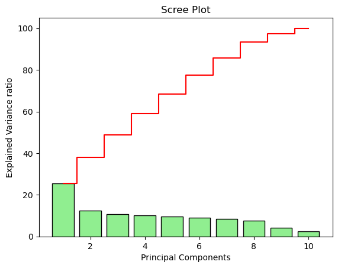

```python
## scree plot
plt.bar(range(1,len(var_exp)+1),var_exp,align='center',color='lightgreen',edgecolor='black',label='Explained Variance')
plt.step(range(1,len(var_exp)+1),cum_var_exp,where='mid',color='red',label='Cummulative Explained Variance')
plt.xlabel('Principal Components')
plt.ylabel('Explained Variance ratio')
plt.title('Scree Plot')

plt.show()
```

- We can see that 90-95% of the variance in data is explained by 8 principal components.

# 15. Apply K-means clustering and segment the data. (using PCA transformed data)

```python
pca = PCA(n_components=8)

pca_df = pd.DataFrame(pca.fit_transform(nf_df), columns=['PC1', 'PC2', 'PC3', 'PC4', 'PC5', 'PC6', 'PC7', 'PC8'])
pca_df.head()
```

|  | PC1 | PC2 | PC3 | PC4 | PC5 | PC6 | PC7 | PC8 |
| --- | --- | --- | --- | --- | --- | --- | --- | --- |
| 0 | 0.207603 | -0.886559 | 0.137886 | 1.328217 | 1.414393 | 0.503316 | -0.338601 | -0.075843 |
| 1 | -0.654307 | -0.708469 | 0.478694 | -0.324486 | -0.856843 | 1.592500 | -0.662675 | -0.155514 |
| 2 | -0.554291 | -0.379787 | 2.221516 | -0.958277 | 1.194886 | -0.359404 | -0.968819 | -0.418605 |
| 3 | -0.550575 | 0.189386 | 0.370309 | -0.028686 | -1.176602 | 0.284129 | -0.112128 | 0.918994 |
| 4 | 0.623087 | -1.225869 | -1.454461 | 0.979574 | 0.569997 | -0.885464 | -0.540414 | 0.022821 |

# a) Finding a optimal K value using elbow plot

```python
# creating an emoty list to store sum of squared distances(SSD)
ssd = []

#Define a range of k values to try
k_values = range(1,13) #adjust as needed

#perform k-means clustering for each k and compute ssd
for k in k_values:
    clusters= KMeans(n_clusters=k, random_state=100)
    clusters.fit(pca_df)
    ssd.append(clusters.inertia_)
```

```python
cluster_df = pd.DataFrame({'k': k_values, 'ssd': ssd})
```

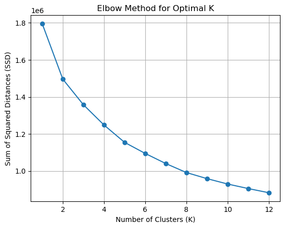

```python
plt.plot(k_values, ssd, marker='o', linestyle='-')
plt.xlabel('Number of Clusters (K)')
plt.ylabel('Sum of Squared Distances (SSD)')
plt.title('Elbow Method for Optimal K')
plt.grid(True)
plt.show()
```

- we can see a clear elbow at 2, so taking k as 2.

# b) Building a Kmeans clustering model using obtained k value

```python
optimal_k = 2

kmeans_model = KMeans(n_clusters=optimal_k, random_state=100)
kmeans_model.fit(pca_df)
```

```
KMeans(n_clusters=2, random_state=100)
```

```python
label = pd.DataFrame(kmeans_model.labels_, columns=['Label'])
```

```python
kmeans_df=pca_df.join(label)
kmeans_df.head()
```

|  | PC1 | PC2 | PC3 | PC4 | PC5 | PC6 | PC7 | PC8 | Label |
| --- | --- | --- | --- | --- | --- | --- | --- | --- | --- |
| 0 | 0.207603 | -0.886559 | 0.137886 | 1.328217 | 1.414393 | 0.503316 | -0.338601 | -0.075843 | 0 |
| 1 | -0.654307 | -0.708469 | 0.478694 | -0.324486 | -0.856843 | 1.592500 | -0.662675 | -0.155514 | 0 |
| 2 | -0.554291 | -0.379787 | 2.221516 | -0.958277 | 1.194886 | -0.359404 | -0.968819 | -0.418605 | 0 |
| 3 | -0.550575 | 0.189386 | 0.370309 | -0.028686 | -1.176602 | 0.284129 | -0.112128 | 0.918994 | 0 |
| 4 | 0.623087 | -1.225869 | -1.454461 | 0.979574 | 0.569997 | -0.885464 | -0.540414 | 0.022821 | 1 |

```python
kmeans_df['Label'].value_counts()
```

```
0    115924
1     76620
Name: Label, dtype: int64
```

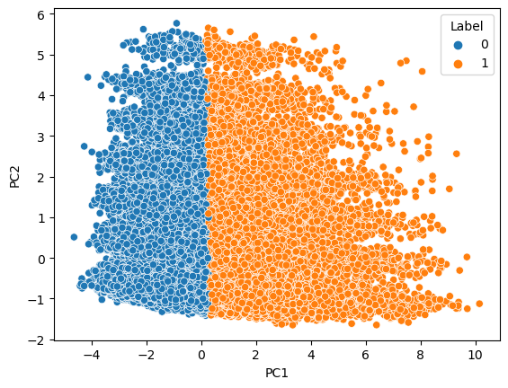

```python
sns.scatterplot(kmeans_df['PC1'],kmeans_df['PC2'],hue='Label',data=kmeans_df)
plt.show()
```

# c) Compute silhouette score for evaluating the quality of the K Means clustering technique

```python
# Compute the silhouette score
silhouette_avg = silhouette_score(pca_df, kmeans_model.labels_)

print(f"Silhouette Score: {silhouette_avg}")
```

```
Silhouette Score: 0.1602854511156476
```

# 16. Applying Agglomerative clustering and segmenting the data (using PCA transformed data)

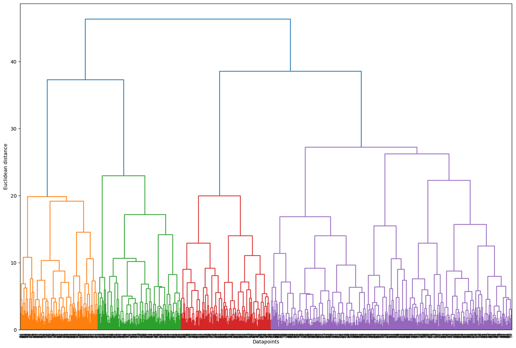

```python
plt.figure(figsize=[18,12])
merg = linkage(pca_df.head(1000),method='ward')
dendrogram(merg, leaf_rotation=90,)
plt.xlabel('Datapoints')
plt.ylabel('Euclidean distance')
plt.show()
```

# a) Finding optimal K value using dendrogram

```python
for i in range(2,15):
    hier = AgglomerativeClustering(n_clusters=i)
    hier = hier.fit(pca_df.head(1000))
    labels = hier.fit_predict(pca_df.head(1000))
    print(i,silhouette_score(pca_df.head(1000), labels))
```

```
2 0.13292456848999415
3 0.11388717314712136
4 0.12850452514909608
5 0.08258951878977087
6 0.08983186018061087
7 0.0921204470897279
8 0.09200452131363258
9 0.09776934977484197
10 0.10273353696434569
11 0.1071191669331312
12 0.10456164521650618
13 0.09871831897034243
14 0.09224445012270478
```

- Highest silhoette score is found at cluster 2 - 0.13

# b) Building Agglomerative clustering model

- Highest silhouette score found at 2nd cluster, so taking k as 2.

```python
hie_cluster = AgglomerativeClustering(n_clusters=2, affinity='euclidean',linkage='ward')
hie_cluster_model = hie_cluster.fit(pca_df.head(1000))
```

```python
df_label1 = pd.DataFrame(hie_cluster_model.labels_, columns=['Labels'])
df_label1.head(10)
```

|  | Labels |
| --- | --- |
| 0 | 0 |
| 1 | 0 |
| 2 | 0 |
| 3 | 0 |
| 4 | 0 |
| 5 | 0 |
| 6 | 0 |
| 7 | 0 |
| 8 | 1 |
| 9 | 0 |

```python
df_hier = df.join(df_label1)
df_hier.head()
```

|  | fit | bust size | weight | rating | rented for | body type | category | height | size | age | Labels |
| --- | --- | --- | --- | --- | --- | --- | --- | --- | --- | --- | --- |
| 0 | 0 | 39 | 137.0 | 10.0 | 5 | 3 | 44 | 68.0 | 14 | 28.0 | 0.0 |
| 1 | 0 | 37 | 132.0 | 10.0 | 3 | 6 | 20 | 66.0 | 12 | 36.0 | 0.0 |
| 2 | 0 | 37 | 135.0 | 10.0 | 4 | 3 | 45 | 64.0 | 4 | 49.0 | 0.0 |
| 3 | 0 | 38 | 135.0 | 8.0 | 2 | 4 | 16 | 65.0 | 8 | 34.0 | 0.0 |
| 4 | 0 | 37 | 145.0 | 10.0 | 6 | 1 | 20 | 69.0 | 12 | 27.0 | 0.0 |

# C) Computing silhouette score to evaluate quality of Agglomerative clustering

```python
silhouette_avg = silhouette_score(pca_df.head(1000), hie_cluster.labels_)

print(f"Silhouette Score: {silhouette_avg}")
```

```
Silhouette Score: 0.13292456848999415
```

The silhouette score is 0.13

# 17. Bivariate analysis between cluster labels and different features.

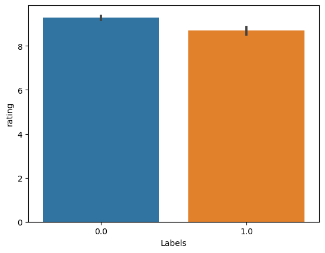

```python
sns.barplot(df_hier['Labels'], df_hier['rating'])
plt.show()
```

- We can see that ratings are high in cluster 0 than cluster 1

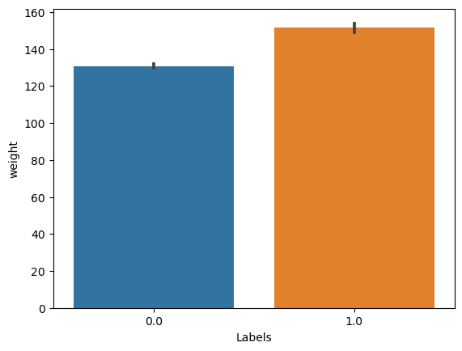

```python
sns.barplot(df_hier['Labels'], df_hier['weight'])
plt.show()
```

- The weight of the customers in cluster 1 is higher than cluster 0.

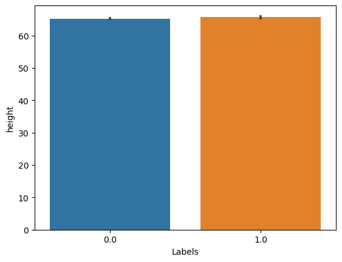

```python
sns.barplot(df_hier['Labels'], df_hier['height'])
plt.show()
```

- The height of the customers in both the clusters is almost equal.

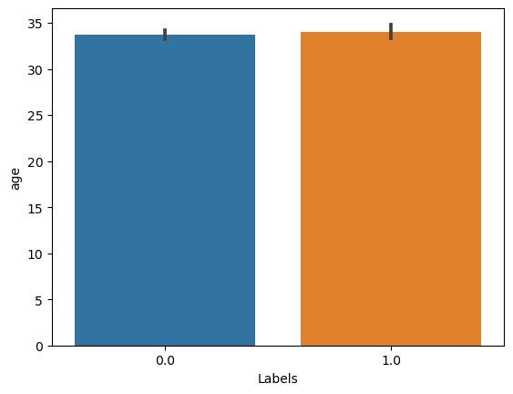

```python
sns.barplot(df_hier['Labels'], df_hier['age'])
plt.show()
```

- Similarly the age is also similar for both the clusters.

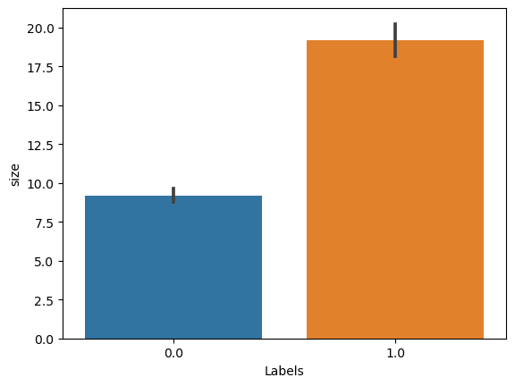

```python
sns.barplot(df_hier['Labels'], df_hier['size'])
plt.show()
```

- There is a clear difference in the size preference of customers in both the clusters.
- Clsuter 1 have higher size preference.